# HW6

# Question 4 and 5:

The linear model gives us the coeficients and using this model we can predict.  
So using the same data as train data we will have: We will plot the predicted value of sale versus the real value.  
The line indicates `y=x` which is our desired line.

```r
# HW6 -4:
# We will use the 10 most correlated variables:
library(ggplot2)
library(gridExtra)
library(GGally)

#-----------------------------------------
# from question 1 we have the 10 most correlated variables
# to SalePrice
house = read.csv("/Users/shervin/Downloads/house/train.csv")
fit <- lm(SalePrice ~ OverallQual +
           GrLivArea +
           GarageCars +
           GarageArea +
           TotalBsmtSF +
           X1stFlrSF +
           FullBath +
           TotRmsAbvGrd +
           YearBuilt +
           YearRemodAdd, data = house)
summary(fit)
```

```
##
## Call:
## lm(formula = SalePrice ~ OverallQual + GrLivArea + GarageCars +
##     GarageArea + TotalBsmtSF + X1stFlrSF + FullBath + TotRmsAbvGrd +
##     YearBuilt + YearRemodAdd, data = house)
##
## Residuals:
##     Min      1Q  Median      3Q     Max
## -489958  -19316   -1948   16020  290558
##
## Coefficients:
##                Estimate Std. Error t value Pr(>|t|)
## (Intercept)  -1.186e+06  1.291e+05  -9.187  < 2e-16 ***
## OverallQual   1.960e+04  1.190e+03  16.472  < 2e-16 ***
## GrLivArea     5.130e+01  4.233e+00  12.119  < 2e-16 ***
## GarageCars    1.042e+04  3.044e+03   3.422 0.000639 ***
## GarageArea    1.495e+01  1.031e+01   1.450 0.147384
## TotalBsmtSF   1.986e+01  4.295e+00   4.625 4.09e-06 ***
## X1stFlrSF     1.417e+01  4.930e+00   2.875 0.004097 **
## FullBath     -6.791e+03  2.682e+03  -2.532 0.011457 *
## TotRmsAbvGrd  3.310e+01  1.119e+03   0.030 0.976404
## YearBuilt     2.682e+02  5.035e+01   5.328 1.15e-07 ***
## YearRemodAdd  2.965e+02  6.363e+01   4.659 3.47e-06 ***
## ---
## Signif. codes:  0 '***' 0.001 '**' 0.01 '*' 0.05 '.' 0.1 ' ' 1
##
## Residual standard error: 37920 on 1449 degrees of freedom
## Multiple R-squared:  0.7737, Adjusted R-squared:  0.7721
## F-statistic: 495.4 on 10 and 1449 DF,  p-value: < 2.2e-16
```

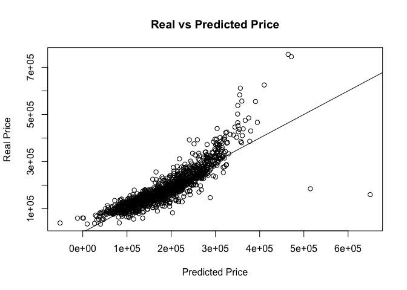

```r
#-----------------------------------------
# Predicting using the fit model:
prediction <- predict(fit, newdata = house)

#-----------------------------------------
# Ploting the real vs predicted price:
plot(prediction, house$SalePrice, xlab = "Predicted Price", ylab = "Real Price",main = "Real vs Predicted Price")
abline(a=0, b=1)
```

```r
#-----------------------------------------
# Q5:
# Finding the Rsqured:
RS <- summary(fit)$r.squared
print(RS)
```

```
## [1] 0.7736928
```

```r
#-----------------------------------------
#f statistic:
summary(fit)
```

```
##
## Call:
## lm(formula = SalePrice ~ OverallQual + GrLivArea + GarageCars +
##     GarageArea + TotalBsmtSF + X1stFlrSF + FullBath + TotRmsAbvGrd +
##     YearBuilt + YearRemodAdd, data = house)
##
## Residuals:
##     Min      1Q  Median      3Q     Max
## -489958  -19316   -1948   16020  290558
##
## Coefficients:
##                Estimate Std. Error t value Pr(>|t|)
## (Intercept)  -1.186e+06  1.291e+05  -9.187  < 2e-16 ***
## OverallQual   1.960e+04  1.190e+03  16.472  < 2e-16 ***
## GrLivArea     5.130e+01  4.233e+00  12.119  < 2e-16 ***
## GarageCars    1.042e+04  3.044e+03   3.422 0.000639 ***
## GarageArea    1.495e+01  1.031e+01   1.450 0.147384
## TotalBsmtSF   1.986e+01  4.295e+00   4.625 4.09e-06 ***
## X1stFlrSF     1.417e+01  4.930e+00   2.875 0.004097 **
## FullBath     -6.791e+03  2.682e+03  -2.532 0.011457 *
## TotRmsAbvGrd  3.310e+01  1.119e+03   0.030 0.976404
## YearBuilt     2.682e+02  5.035e+01   5.328 1.15e-07 ***
## YearRemodAdd  2.965e+02  6.363e+01   4.659 3.47e-06 ***
## ---
## Signif. codes:  0 '***' 0.001 '**' 0.01 '*' 0.05 '.' 0.1 ' ' 1
##
## Residual standard error: 37920 on 1449 degrees of freedom
## Multiple R-squared:  0.7737, Adjusted R-squared:  0.7721
## F-statistic: 495.4 on 10 and 1449 DF,  p-value: < 2.2e-16
```

Because `R Squared` is `0.77` and is larger than `0.5` we can suppose that it is not bad. Algtough we cannot say that `R Squared` use using a constant treshhold in all the problems and it depends on the nature of the problem, but in this case we can say th at the closer it is to 1 the better the `R Squared` is.  
For the `R Squared` we used the `summary` of our model.  
Regarding the `F-statistic`: the f statistic has a null hypothesis that all our coeficients are zero. Our model’s f statistic is very high therefore its p-value is very low because it does not satistfy the assumption that we’ve made.

## Question 6 and 7:

We will look at the `p-values` of the ten variables that we chose. From these variables we will chose does that have a lesser `p-value`.  
We will again use the `summary` of our model to find these variables.Our new prediction is based on these new variables. The line indicates `y=x` which is our desired line.

```r
# HW6-6:
library(ggplot2)
library(gridExtra)
library(GGally)

#-----------------------------------------
# We will use does which have ** and *** in the p-value:
house = read.csv("/Users/shervin/Downloads/house/train.csv")
fit_new <- lm(SalePrice ~
            OverallQual +
            GrLivArea +
            GarageCars +
            TotalBsmtSF +
            X1stFlrSF +
            YearBuilt +
            YearRemodAdd, data = house)
summary(fit_new)
```

```
##
## Call:
## lm(formula = SalePrice ~ OverallQual + GrLivArea + GarageCars +
##     TotalBsmtSF + X1stFlrSF + YearBuilt + YearRemodAdd, data = house)
##
## Residuals:
##     Min      1Q  Median      3Q     Max
## -471221  -19922   -1681   16246  291326
##
## Coefficients:
##                Estimate Std. Error t value Pr(>|t|)
## (Intercept)  -1.075e+06  1.217e+05  -8.833  < 2e-16 ***
## OverallQual   1.949e+04  1.190e+03  16.377  < 2e-16 ***
## GrLivArea     4.768e+01  2.713e+00  17.576  < 2e-16 ***
## GarageCars    1.381e+04  1.820e+03   7.586 5.85e-14 ***
## TotalBsmtSF   2.174e+01  4.249e+00   5.117 3.53e-07 ***
## X1stFlrSF     1.407e+01  4.925e+00   2.856  0.00435 **
## YearBuilt     2.292e+02  4.799e+01   4.777 1.96e-06 ***
## YearRemodAdd  2.768e+02  6.337e+01   4.367 1.35e-05 ***
## ---
## Signif. codes:  0 '***' 0.001 '**' 0.01 '*' 0.05 '.' 0.1 ' ' 1
##
## Residual standard error: 38010 on 1452 degrees of freedom
## Multiple R-squared:  0.7722, Adjusted R-squared:  0.7711
## F-statistic: 703.2 on 7 and 1452 DF,  p-value: < 2.2e-16
```

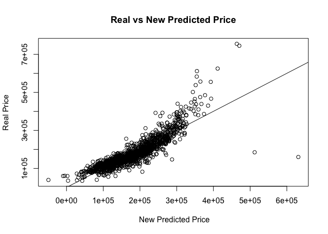

```r
#-----------------------------------------
# Predicting using the new fit model:
prediction_new <- predict(fit_new, newdata = house)

#-----------------------------------------
# Ploting the real vs predicted price in the new model:
plot(prediction_new, house$SalePrice, xlab = " New Predicted Price", ylab = "Real Price",main = "Real vs New Predicted Price")
abline(a=0, b=1)
```

```r
#-----------------------------------------
# Q7:

# Mean of resduals must be close to zero:
print(mean(fit_new$residuals))
```

```
## [1] 7.434777e-13
```

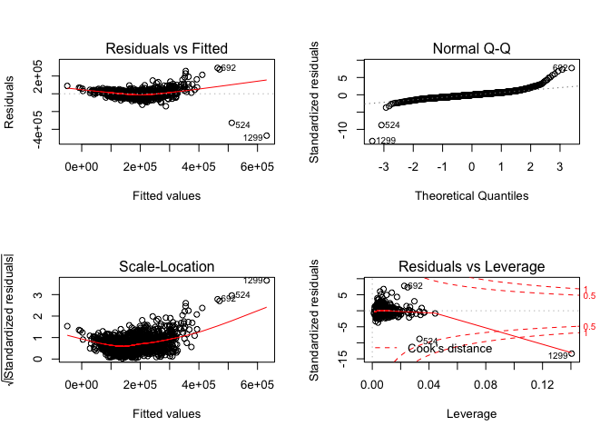

```r
#-----------------------------------------
#Normality:(top-right plot we see the fitted plot)
par(mfrow=c(2,2))
plot(fit_new)
```

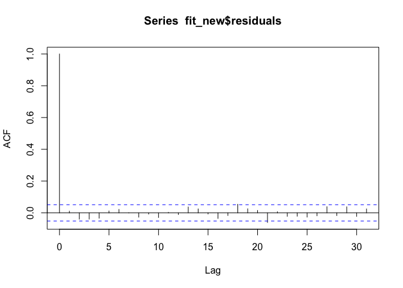

```r
#-----------------------------------------
# Constant Variance:
# From the top left and bottom left we see patterns that are
# not flat, there it is no Constance Variance, therefore
# our assumption of constant variance does not apply here

#-----------------------------------------
# Independece or autocorrelation test:
par(mfrow=c(1,1))
acf(fit_new$residuals) # not corollated from the graph
```